# Linear Regression In-Class Exercises

Maria Cuellar

2026-10-17

```r
library(tidyverse)

dat_riverton <- read_csv("/Users/mariacuellar/Github/crim_data_analysis/data/riverton-crime1.csv")
```

# Linear Regression

We will examine the relationship between the number of prior arrests and time served.

## Question 1

Create a scatterplot with `num_prior_arrests` on the x-axis and `time_served_months` on the y-axis.

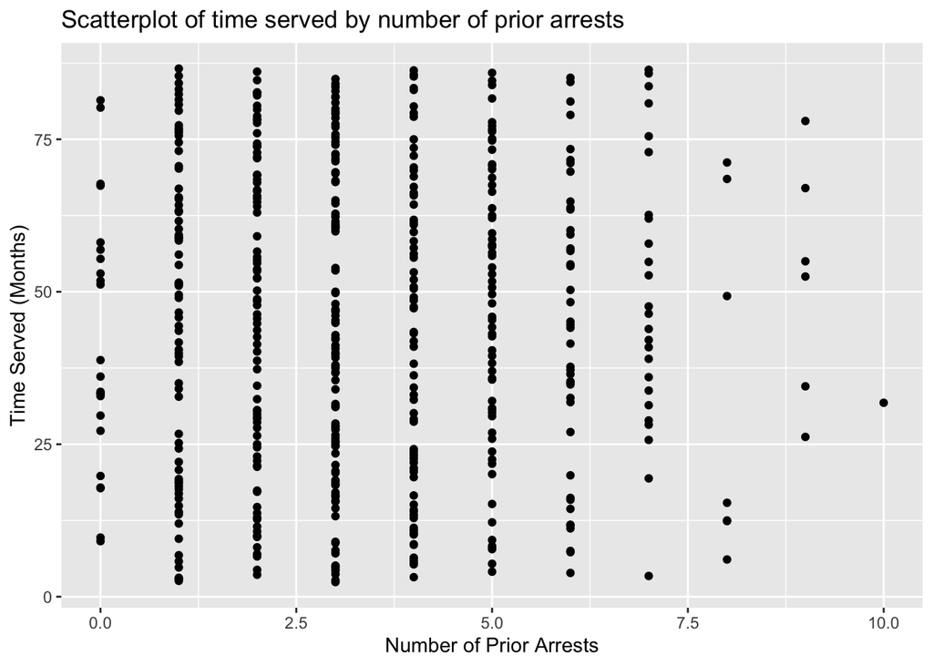

```r
dat_riverton %>%
  ggplot(aes(x = num_prior_arrests, y = time_served_months)) + geom_point() +
  labs(x="Number of Prior Arrests",
       y="Time Served (Months)",
       title="Scatterplot of time served by number of prior arrests")
```

Describe the relationship. Is it positive or negative? Does it look approximately linear?

**Answer:** It might be linear, but it is too spread out to tell. Thus, I wouldn’t say it’s positive or negative.

## Question 2

Fit a linear regression where you regress time served onto number of prior arrests.

```r
model_riverton <- lm(time_served_months ~ num_prior_arrests, data = dat_riverton)
summary(model_riverton)
```

```
##
## Call:
## lm(formula = time_served_months ~ num_prior_arrests, data = dat_riverton)
##
## Residuals:
##     Min      1Q  Median      3Q     Max
## -42.067 -21.036  -0.005  21.205  42.288
##
## Coefficients:
##                   Estimate Std. Error t value Pr(>|t|)
## (Intercept)       44.23440    2.15625  20.514   <2e-16 ***
## num_prior_arrests  0.07739    0.54185   0.143    0.886
## ---
## Signif. codes:  0 '***' 0.001 '**' 0.01 '*' 0.05 '.' 0.1 ' ' 1
##
## Residual standard error: 24.41 on 498 degrees of freedom
## Multiple R-squared:  4.096e-05,  Adjusted R-squared:  -0.001967
## F-statistic: 0.0204 on 1 and 498 DF,  p-value: 0.8865
```

Which variable is the outcome/dependent variable?

**Answer:** The time served in months is the outcome/dependent variable.

Which variable is the explanatory/independent variable?

**Answer:** The number of prior arrests is the independent variable.

## Question 3

Use the regression output to write the regression equation.

Predicted time served = 44.23 + 0.077 (number of prior arrests)

Interpret the slope in words.

**Answer:** Each additional prior arrest is associated with an additional 0.077 of a month in terms of time served, on average, with a p-value of 0.89. Thus, the relationship is not statistically significant at the 0.05 level.

## Question 4

Add the regression line to the scatterplot.

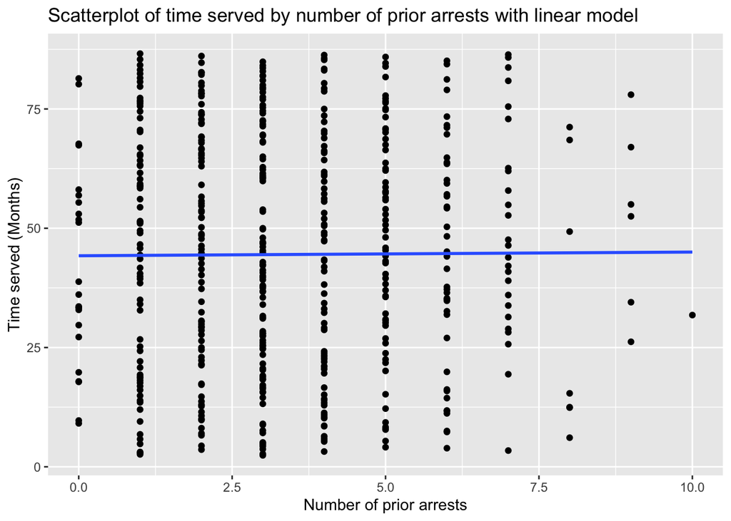

```r
dat_riverton %>%
  ggplot(aes(x = num_prior_arrests, y = time_served_months)) + geom_point() +
  geom_smooth(method = "lm", se = FALSE)+
  labs(x = "Number of prior arrests",
       y = "Time served (Months)",
       title = "Scatterplot of time served by number of prior arrests with linear model")
```

Does the regression line seem like a reasonable summary of the relationship?

**Answer:**

Since the line is just flat, and we’ve seen that the relationship is not statistically significantly different from zero, this seems like a reasonable summary. Basically, there does not seem to be a strong linear relationship between the two variables.

## Question 5

Use the model to predict time served for a person with 5 prior arrests.

```r
predict(model_riverton, newdata = data.frame(num_prior_arrests = 5))
```

```
##        1
## 44.62135
```

The predicted time served for a person with 5 prior arrests is 44.62 months.

## Question 6

Look at the R-squared value in the regression output.

```r
summary(model_riverton)
```

```
##
## Call:
## lm(formula = time_served_months ~ num_prior_arrests, data = dat_riverton)
##
## Residuals:
##     Min      1Q  Median      3Q     Max
## -42.067 -21.036  -0.005  21.205  42.288
##
## Coefficients:
##                   Estimate Std. Error t value Pr(>|t|)
## (Intercept)       44.23440    2.15625  20.514   <2e-16 ***
## num_prior_arrests  0.07739    0.54185   0.143    0.886
## ---
## Signif. codes:  0 '***' 0.001 '**' 0.01 '*' 0.05 '.' 0.1 ' ' 1
##
## Residual standard error: 24.41 on 498 degrees of freedom
## Multiple R-squared:  4.096e-05,  Adjusted R-squared:  -0.001967
## F-statistic: 0.0204 on 1 and 498 DF,  p-value: 0.8865
```

R-squared = 4.096e-05 = 0.000041.

Interpret the R-squared in words.

**Answer:** The R-squared is very very low. This means that the relationship between the two variables is very weak.

Can we conclude that having more prior arrests **causes** a person to serve more time? Why or why not?

**Answer:** No. The R-squared only tells us about the strength of the relationship, or how spread out the points are around the regression line.

Linear regression doesn’t ever tell us that there is a causal relationship, on its own. More assumptions need to be met.

Additionally, this relationship is not statistically significant. So, even if the model were causal, there would be no effect in this case.

## Question 7 (20 points)

Now let’s look at the income_2.csv dataset.

1. Load the data

```r
dat_income <- read_csv("/Users/mariacuellar/Github/crim_data_analysis/data/income_2.csv")
```

2. Draw the scatterplot (without a line of best fit) (2 points)

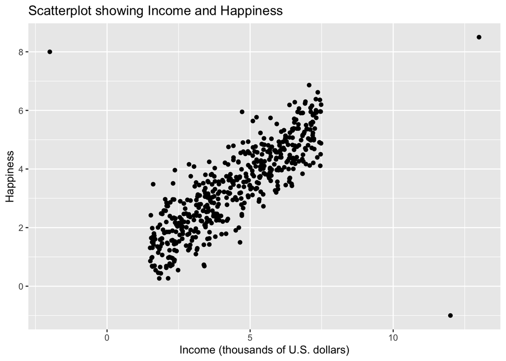

```r
dat_income %>%
  ggplot(aes(x=income,y=happiness)) + geom_point() +
  labs(x="Income (thousands of U.S. dollars)",
       y="Happiness",
       title="Scatterplot showing Income and Happiness")
```

3. Describe the scatterplot, calculate correlation if appropriate (5 points)

**Answer:** Direction: Positive direction of association. Form: Linear. Strength: Strong relationship. Unusual features: There are definitely three outliers.

It is not appropriate to calculate correlation with these strong outliers. So, I’ll calculate it with the outliers and without, to compare.

```r
# fit linear model
model_income <- lm(happiness ~ income, data = dat_income)

# define new dataset without influential outliers
dat_income_nooutliers <- dat_income %>%
  filter(cooks.distance(model_income) <= 0.05)

# calculate correlation with and without outliers
dat_income %>% summarize(cor=cor(income, happiness))
```

```
## # A tibble: 1 × 1
##     cor
##   <dbl>
## 1 0.780
```

```r
dat_income_nooutliers %>% summarize(cor=cor(income, happiness))
```

```
## # A tibble: 1 × 1
##     cor
##   <dbl>
## 1 0.869
```

The correlation with influential outliers is .78 and without is .87.

4. Fit a linear model and report the estimated i) slope, ii) y-intercept, and iii) p-value for the slope. (5 points)

```r
# fit model
model_income_nooutliers <- lm(happiness ~ income, data = dat_income_nooutliers)

# give summary with and without outliers
summary(model_income)
```

```
##
## Call:
## lm(formula = happiness ~ income, data = dat_income)
##
## Residuals:
##     Min      1Q  Median      3Q     Max
## -9.1306 -0.4921 -0.0224  0.4988  8.6770
##
## Coefficients:
##             Estimate Std. Error t value Pr(>|t|)
## (Intercept)  0.58125    0.10937   5.315 1.61e-07 ***
## income       0.62911    0.02258  27.862  < 2e-16 ***
## ---
## Signif. codes:  0 '***' 0.001 '**' 0.01 '*' 0.05 '.' 0.1 ' ' 1
##
## Residual standard error: 0.9232 on 499 degrees of freedom
## Multiple R-squared:  0.6087, Adjusted R-squared:  0.6079
## F-statistic: 776.3 on 1 and 499 DF,  p-value: < 2.2e-16
```

```r
summary(model_income_nooutliers)
```

```
##
## Call:
## lm(formula = happiness ~ income, data = dat_income_nooutliers)
##
## Residuals:
##      Min       1Q   Median       3Q      Max
## -2.02195 -0.48540  0.03816  0.45760  2.38128
##
## Coefficients:
##             Estimate Std. Error t value Pr(>|t|)
## (Intercept)  0.22618    0.08739   2.588  0.00993 **
## income       0.70850    0.01812  39.101  < 2e-16 ***
## ---
## Signif. codes:  0 '***' 0.001 '**' 0.01 '*' 0.05 '.' 0.1 ' ' 1
##
## Residual standard error: 0.7187 on 497 degrees of freedom
## Multiple R-squared:  0.7547, Adjusted R-squared:  0.7542
## F-statistic:  1529 on 1 and 497 DF,  p-value: < 2.2e-16
```

**Answer:** With the influential outliers there is an estimated slope of 0.63 (p-value < 0.001) and a y-intercept of 0.58.

Removing the influential outliers incrased the slope, and the statistical signficance remained.

5. Test the assumptions of linear regression and assess the goodness of fit. (5 points)

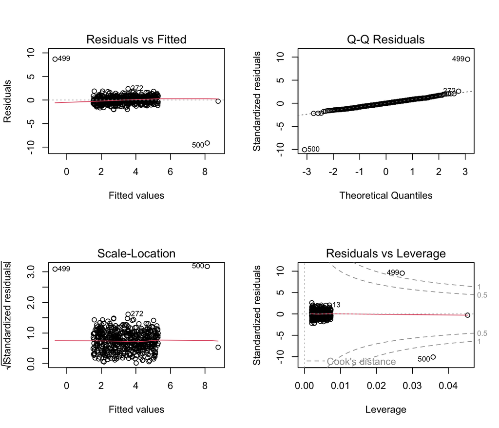

```r
# show diagnostic plots both with and without outliers
par(mfrow=c(2,2))
plot(model_income)
```

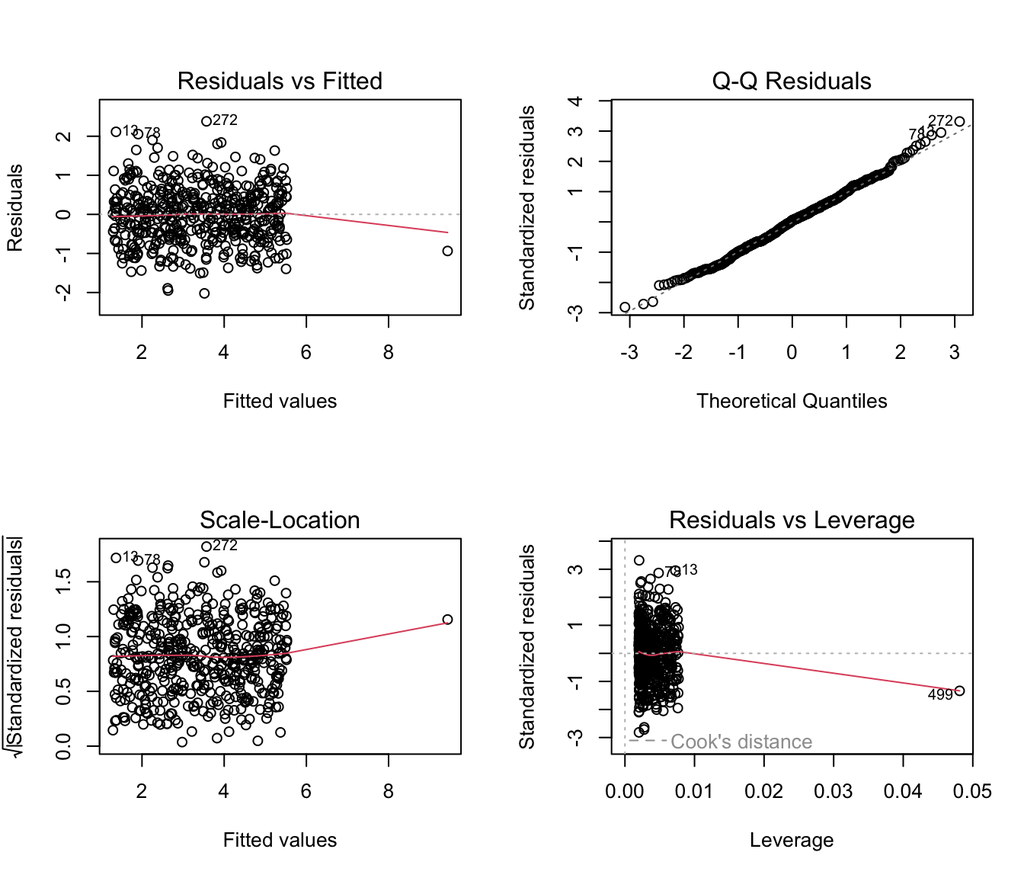

```r
plot(model_income_nooutliers)
```

```r
par(mfrow=c(1,1))
```

**Answer:** Homoscedasticity: Satisfied because the variability along the x-axis seems constant, and the red curve on the scale location plot looks mostly flat.

Independence: There is no evidence of dependencies in the data.

Normality: Satisfied since the points lie mostly on the diagonal line in the qq plot.

Linearity: Satisfied because the scatterplot looks like it has a linear association, and the residuals vs. fitted plot has no unusual features or trends.

No influential outliers: Not satisfied as shown by the points outside the Cook’s distance of 0.5, so I removed them. I present results with and without influential outliers.

6. Interpret the slope coefficient. (3 points)

```r
model_income$coefficients[2]
```

```
##    income
## 0.6291102
```

```r
model_income_nooutliers$coefficients[2]
```

```
##    income
## 0.7084986
```

**Answer:**

When removing the influential outliers, the estimated slope coefficient increased from 0.63 to 0.71. I will read the inferential result without outliers.

Each additional $1,000 is associated with an additional 0.71 units of happiness on average, with p-value < 0.001